# Multivariate Data Analysis Assignment #8

2018170865 산업경영공학부 박재현

2021. 6. 21.

```r
suppressMessages({
  library(clValid)
  library(plotrix)
  library(NbClust) #NbClust 함수
  library(cluster) # clusplot 함수
  library(factoextra) #fviz_nbclust 함수
  library(fpc)
  library(factoextra)
  library(dbscan)
})
```

## [Q1] 데이터셋 선정하기

Dataset: Kaggle Clustering 데이터셋 중 1개 선택  
Kaggle 사이트의 Datasets 항목에서 “clustering”을 키워드로 검색하면 총 412개의 데이터셋이 아래와 같이 검색 됩니다.

이 중에서 군집화 후 각 군집에 대한 속성 분석이 유의미할(또는 재미있을) 것으로 판단되는 데이터셋 하나를 선정하고 본인이 해당 데이터셋을 선정한 이유를 설명하시오.

Credit Card Dataset for Clustering 데이터셋[https://www.kaggle.com/arjunbhasin2013/ccdata]을 선택하였다. 신용카드 고객의 정보를 사용하여 마케팅 전략을 만든다는 목표가 흥미로웠다. 사용 행동 패턴을 클러스터 하여 신용카드 고객의 그룹을 나눠보고 어떠한 결론이 나타나는지 알아보고 싶다.

#[K-Means Clustering]

## [Q2] clValid( ) 함수를 사용하여 K-Means Clustering의 군집 수를 2개부터 K(데이터의 규모에 따라서 본인이 적절히 선정 할 것)개까지 증가시켜 가면서 internal 및 stability 관련 타당성 지표 값들을 산출하시오. 총 소요 시간은 얼마인가? Dunn index와 Silhouette index 기준으로 가장 최적의 군집 수는 몇 개로 판별이 되었는가?

missing value가 CREDIT_LIMIT 변수에 1개, MINIMUM_PAYMENTS에 313개가 있으므로, 해당 부분을 제거해도 전체 데이터가 8950개라서 큰 영향을 미치지 않을 것이다.

[output not shown]

```r
cc <- na.omit(creditcard)

cc.stand <- scale(cc[-1])
cc.stand <- data.frame(cc.stand)
head(cc.stand)
```

```r
summary(cc.clValid)
```

```
Clustering Methods:
 kmeans

Cluster sizes:
 2 3 4 5 6

Validation Measures:
                             2         3         4         5         6

kmeans APN              0.1287    0.1368    0.1972    0.1312    0.1419
       AD               4.7240    4.5346    4.4797    4.1811    4.0186
       ADM              0.8364    0.8936    1.0269    0.7113    0.6003
       FOM              0.9624    0.9247    0.9139    0.8939    0.8537
       Connectivity  1052.7202 1373.3012 1358.4393 1650.0857 1979.8357
       Dunn             0.0061    0.0049    0.0048    0.0076    0.0071
       Silhouette       0.2089    0.1864    0.1891    0.2050    0.1928

Optimal Scores:
```

|  | Score | Method | Clusters |
| --- | --- | --- | --- |
| APN | 0.1287 | kmeans | 2 |
| AD | 4.0186 | kmeans | 6 |
| ADM | 0.6003 | kmeans | 6 |
| FOM | 0.8537 | kmeans | 6 |
| Connectivity | 1052.7202 | kmeans | 2 |
| Dunn | 0.0076 | kmeans | 5 |
| Silhouette | 0.2089 | kmeans | 2 |

```
NA
```

## [Q3] [Q2]에서 선택된 군집의 수를 사용하여 K-Means Clustering을 10회 반복하고 회차마다 각 군집의 Centroid와 Size를 확인해 보시오. 10회 반복시 몇 가지 경우의 군집화 결과물이 도출되었으며 각 경우의 군집화는 몇 번 반복되어 발생하는지 확인해 보시오.

10회 반복시 9회의 군집화 결과물이 도출되었다(7, 8번째 군집이 동일하게 추출), initial point에 따라서 군집이 조금 다르게 수렴된다고 결론지을 수 있다. 각 군집의 반복수는 4, 5, 6중에 하나의 값이 나오고, 군집의 숫자가 적어서 빠르게 수렴된다고 생각할 수 있다.

| 순서 | iter | 크기 |
| --- | --- | --- |
| 1 | 4번 | (2345, 3746, 83, 1105, 1357) |
| 2 | 4번 | (1298, 3291, 2575, 98, 1374) |
| 3 | 5번 | (31, 2533, 1104, 3771, 1197) |
| 4 | 4번 | (4517, 638, 1176, 1344, 961 |
| 5 | 6번 | (1057, 633, 3612, 243, 3091 |
| 6 | 4번 | (56, 1149, 3852, 3310, 269 |
| 7 | 5번 | (3140, 3003, 978, 269, 1246 |
| 8 | 5번 | (3003, 269, 3140, 1246, 978 |
| 9 | 6번 | (2874, 366, 1270, 1029, 3097 |
| 10 | 4번 | (3151, 251, 1248, 976, 3010 |

```r
for (i in 1:10){
  cc.kmc <- kmeans(cc.stand, 5)
  cat('\n', i, "th", " iteration", sep="", '\n')

  for (j in 1:5){
    cc.list[,j] <- c(cc.kmc$size[j], cc.kmc$iter[j], cc.kmc$centers[j,])
  }

  print(round(cc.list, digits = 2))
}
```

```
1th iteration
                           cluster1 cluster2 cluster3 cluster4 cluster5
size                        2345.00  3746.00    83.00  1105.00  1357.00
iter                           4.00       NA       NA       NA       NA
BALANCE                       -0.45    -0.24     1.42     1.47     0.14
BALANCE_FRE                    0.12    -0.34     0.39     0.35     0.41
PURCHASES                     -0.10    -0.34     6.93    -0.24     0.89
ONEOFF_PURCHASES              -0.26    -0.22     6.08    -0.18     0.83
INSTALLMENTS_PURCHASES         0.24    -0.40     5.21    -0.25     0.57
CASH_ADVANCE                  -0.38    -0.17     0.02     1.75    -0.30
PURCHASES_FREQUENCY            0.90    -0.82     1.07    -0.53     1.07
ONEOFF_PURCHASES_FRE          -0.40    -0.36     1.85    -0.24     1.76
PURCHASES_INSTALLMENTS_FRE     1.07    -0.76     1.03    -0.47     0.56
CASH_ADVANCE_FRE              -0.49    -0.07    -0.26     1.77    -0.39
CASH_ADVANCE_TRX              -0.37    -0.15    -0.06     1.67    -0.31
PURCHASES_TRX                  0.07    -0.48     4.63    -0.30     1.15
CREDIT_LIMIT                  -0.35    -0.33     2.15     0.85     0.69
PAYMENTS                      -0.28    -0.25     4.78     0.65     0.36
MINIMUM_PAYMENTS              -0.08    -0.12     1.07     0.50    -0.01
PRC_FULL_PAYMENT               0.39    -0.28     0.79    -0.41     0.38
TENURE                        -0.06    -0.03     0.33    -0.13     0.27

2th iteration
                           cluster1 cluster2 cluster3 cluster4 cluster5
size                        1298.00  3291.00  2575.00    98.00  1374.00
iter                           4.00       NA       NA       NA       NA
BALANCE                       -0.69     0.44    -0.41     1.59     0.24
BALANCE_FRE                   -2.05     0.38     0.32     0.40     0.41
PURCHASES                     -0.30    -0.36    -0.10     6.24     0.90
ONEOFF_PURCHASES              -0.22    -0.25    -0.22     5.48     0.83
INSTALLMENTS_PURCHASES        -0.32    -0.40     0.17     4.67     0.61
CASH_ADVANCE                  -0.32     0.47    -0.38     0.74    -0.18
PURCHASES_FREQUENCY           -0.57    -0.88     0.79     1.08     1.08
ONEOFF_PURCHASES_FRE          -0.38    -0.40    -0.28     1.82     1.73
PURCHASES_INSTALLMENTS_FRE    -0.50    -0.77     0.88     1.05     0.59
CASH_ADVANCE_FRE              -0.49     0.69    -0.49    -0.03    -0.26
CASH_ADVANCE_TRX              -0.37     0.50    -0.38     0.40    -0.18
PURCHASES_TRX                 -0.43    -0.49     0.05     4.29     1.17
CREDIT_LIMIT                  -0.22     0.00    -0.37     2.21     0.73
PAYMENTS                      -0.19    -0.03    -0.28     4.89     0.43
```

[output cut: 164 more lines]

```
PURCHASES                      0.20     4.01    -0.30    -0.21    -0.35
ONEOFF_PURCHASES               0.08     3.50    -0.23    -0.14    -0.24
INSTALLMENTS_PURCHASES         0.32     3.05    -0.28    -0.23    -0.40
CASH_ADVANCE                  -0.36    -0.14    -0.32     1.89    -0.10
PURCHASES_FREQUENCY            1.03     1.12    -0.48    -0.45    -0.82
ONEOFF_PURCHASES_FRE           0.44     1.83    -0.42    -0.17    -0.38
PURCHASES_INSTALLMENTS_FRE     0.91     1.05    -0.40    -0.41    -0.74
CASH_ADVANCE_FRE              -0.46    -0.32    -0.50     1.85     0.11
CASH_ADVANCE_TRX              -0.36    -0.15    -0.37     1.79    -0.04
PURCHASES_TRX                  0.42     3.49    -0.41    -0.25    -0.48
CREDIT_LIMIT                  -0.01     1.65    -0.22     0.97    -0.35
PAYMENTS                      -0.08     2.53    -0.19     0.73    -0.28
MINIMUM_PAYMENTS              -0.08     0.70    -0.30     0.50    -0.02
PRC_FULL_PAYMENT               0.36     0.48     0.43    -0.41    -0.46
TENURE                         0.08     0.32    -0.13    -0.09    -0.02
```

## [Q4] [Q3]에서 가장 빈번하게 발생한 군집화 결과물에 대해서 각 군집별 변수들의 Radar Chart를 도시해보시오. Radar Chart상으로 판단할 때, 군집의 속성이 가장 상이할 것으로 예상되는 두 군집(군집 A와 군집 B로 명명)과, 가장 유사할 것으로 예상되는 두 군집(군집 X와 군집 Y로 명명)을 각각 선택하고 선택 이유를 설명하시오.

```r
cc.kmc1 <- kmeans(cc.stand, 5)

cluster_kmc <- data.frame(cc.stand, clusterID = as.factor(cc.kmc1$cluster))
kmc_summary <- data.frame()

for (i in 1:(ncol(cluster_kmc)-1)){
  kmc_summary = rbind(kmc_summary,
                     tapply(cluster_kmc[,i], cluster_kmc$clusterID, mean))
}

colnames(kmc_summary) <- paste("cluster", c(1:5))
rownames(kmc_summary) <- colnames(cc.stand)
kmc_summary <- round(kmc_summary, digits = 2)
kmc_summary
```

[output not shown]

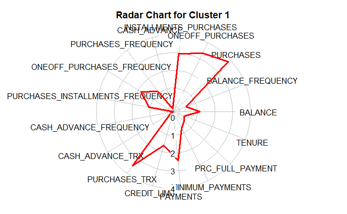

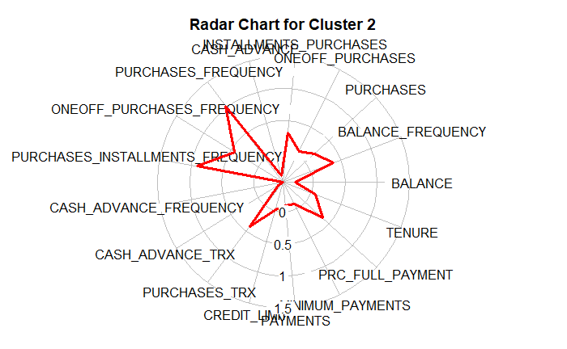

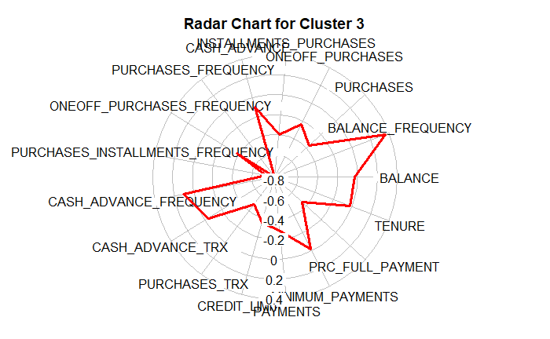

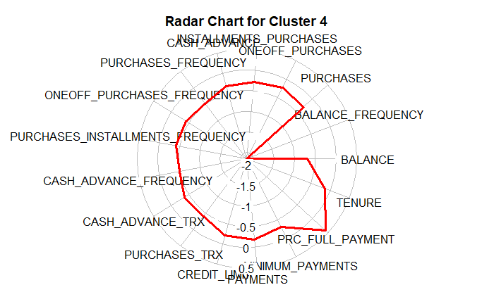

```r
for (i in 1:5){
  plot_title <- paste("Radar Chart for Cluster", i, sep= " ")
  radial.plot(kmc_summary[,i], labels = rownames(kmc_summary),
              rp.type = "p", main = plot_title,
              line.col = "red", lwd = 3, show.grid.labels = 1,
              cex.axis=2)
}
```

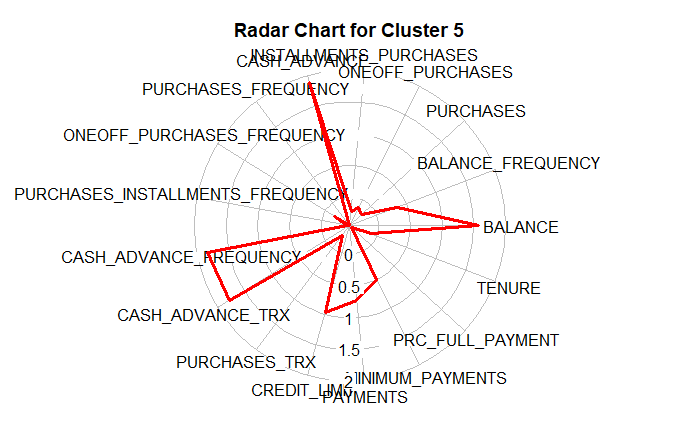

```r
NA
```

## [Q5] [Q4]에서 선택된 군집 A와 군집 B에 대해 각 변수별 평균값 차이에 대한 통계적 검정을 수행하시오.전체 변수 중에서 유의수준 0.05에서 값의 차이가 나타나는 변수의 비중은 얼마인가? 또한 [Q4]에서 선택된 군집 X와 군집 Y에 대해서도 각 변수별 평균값 차이에 대한 통계적 검정을 수행하시오. 이 경우, 전체 변수 중에서 유의수준 0.05에서 값의 차이가 나타나는 변수의 비중은 얼마인가?

```r
kmc_clusterA <- cc.stand[cc.kmc1$cluster == 4,]
kmc_clusterB <- cc.stand[cc.kmc1$cluster == 5,]

kmc_t_result <- data.frame()
for (i in 1:17) {
  kmc_t_result[i,1] <- t.test(kmc_clusterA[,i], kmc_clusterB[,i], alternative = "two.sided")$p.value
}
round(kmc_t_result, digits = 5)
```

|  | V1 |
| --- | --- |
| 1 | 0.00000 |
| 2 | 0.00000 |
| 3 | 0.00000 |
| 4 | 0.00000 |
| 5 | 0.00327 |
| 6 | 0.00000 |
| 7 | 0.37961 |
| 8 | 0.00000 |
| 9 | 0.75787 |
| 10 | 0.00000 |

[output cut: 7 more lines]

> 다른 2개의 군집을 이용하여 검정을 추가로 수행한 결과, 최소 1개의 변수가 상이하다는 결론이 나왔다(군집 1번과 군집 5번). 이는 3번과 5번 군집이 가장 유사한 군집이라고 보기 어려운 근거가 될 수 있다.

```r
kmc_clusterX <- cc.stand[cc.kmc1$cluster == 3,]
kmc_clusterY <- cc.stand[cc.kmc1$cluster == 5,]

kmc_t_result <- data.frame()
for (i in 1:17) {
  kmc_t_result[i,1] <- t.test(kmc_clusterX[,i], kmc_clusterY[,i], alternative = "two.sided")$p.value
}
round(kmc_t_result, digits = 5)
```

|  | V1 |
| --- | --- |
| 1 | 0.00000 |
| 2 | 0.66474 |
| 3 | 0.00000 |
| 4 | 0.00000 |
| 5 | 0.00000 |
| 6 | 0.00000 |
| 7 | 0.00000 |
| 8 | 0.00000 |
| 9 | 0.00000 |
| 10 | 0.00000 |

[output cut: 7 more lines]

# [Hierarchical Clustering]

## [Q6] Distance matrix는 실습 자료에서 제공하는 spearman correlation을 이용한 방식으로 산출한 뒤, hclust( ) 함수의 method 옵션을 “single”과 “complete” 두 가지로 설정한 후 각각에 대한 dendrogram을 그려보고 비교해보시오.

거리 기준을 single로 적용한 경우 y축, height가 낮은 지점에서 군집이 합쳐진다. 그래프에서 보면 식별 되는 결합 구간의 y값이 0.11정도 된다(그 후에는 극단적으로 왼쪽에서 결합이 이뤄진다). 최단거리 기준으로 클러스터링을 하면 그룹핑이 빠르게 끝난다는 점을 볼 수 있고, x축 기준으로 왼쪽의 구간에서 군집이 합쳐지는 경우가 많다.

반면, 거리 기준을 complete로 하는 경우, 군집이 합쳐지는 구간이 상대적으로 y축 기준으로도, x축 기준으로도 다양하다. y축은 마지막 군집이 합쳐지는 값이 2.0이고, x축구 상대적으로 모든 구간에서 군집화가 나타난다.

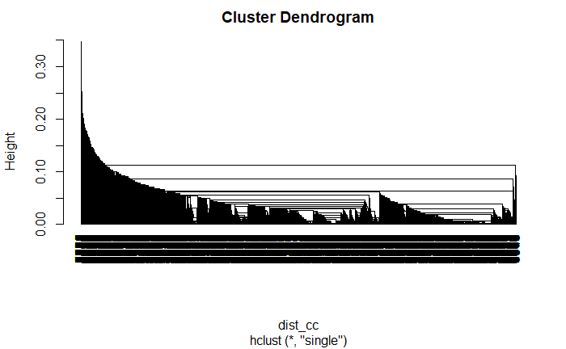

```r
cor_Mat <- cor(t(cc.stand), method = "spearman")
dist_cc <- as.dist(1-cor_Mat)

hr1 <- hclust(dist_cc, method = "single", members=NULL)
hr2 <- hclust(dist_cc, method = "complete", members=NULL)


plot(hr1, hang = -1)
```

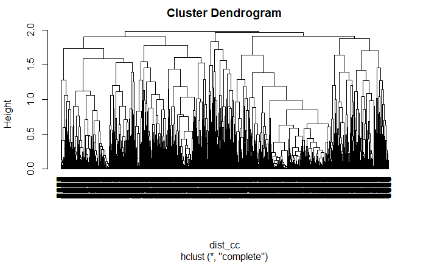

```r
plot(hr2, hang = -1)
```

## [Q7] 각 Linkage로부터 생성된 Dendrogram으로부터 [Q2]에서 선정한 최적 개수의 군집을 각각 찾은 후 각 군집들의 변수값을 활용하여 Radar Chart를 도시해보시오. Radar Chart를 바탕으로 판단할 때, KMeans Clustering과 보다 유사한 결과물이 나오는 방식은 어떤 Linkage인지 본인의 생각을 바탕으로 서술해보시오.

우선, 덴드로그램만으로 비교해봐도 complete linkage가 적절하다. single linkage 방식은 군집이 극단적으로 한쪽에서 군집이 나누어 지기 때문이다. complete linkage의 덴드로그램을 보면 3번째 클러스터를 4번째 클러스와 결합하여 총 4개의 군집으로 형성하여 마케팅 전략을 수립하는 게 적절한 것으로 판단된다.

KMeans 군집화의 Radar Chart와 비교해봐도, complete linkage의 방식이 유사한 결과물이 나온다. KMeans 차트의 5번과 complete 차트의 2번, Kmeans 차트의 2번과, complete 차트의 4번과 5번이 유사하게 나타난다. 반면, single 차트와는 유사한 차트가 보이지 않는다.

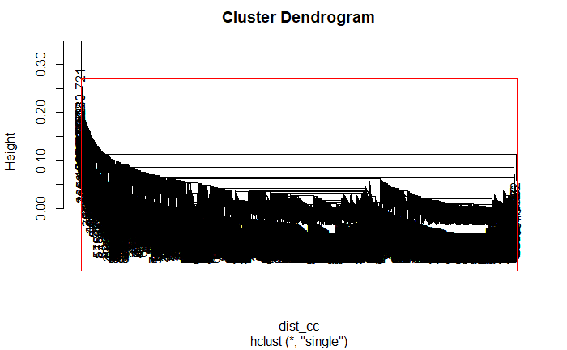

```r
mycl1 <- cutree(hr1, k=5)

plot(hr1)
rect.hclust(hr1, k=5, border="red")
```

```r
cc_hc1 <- data.frame(cc.stand, clusterID = as.factor(mycl1))
hc_summary1 <- data.frame()

for (i in 1:(ncol(cc_hc1)-1)){
  hc_summary1 = rbind(hc_summary1,
                     tapply(cc_hc1[,i], cc_hc1$clusterID, mean))
}

colnames(hc_summary1) <- paste("cluster", c(1:5))
rownames(hc_summary1) <- c(colnames(cc.stand))
round(hc_summary1, digits= 5)
```

|  | cluster 1 | cluster 2 | cluster 3 | cluster 4 | cluster 5 |
| --- | --- | --- | --- | --- | --- |
| BALANCE | -0.00006 | 0.49755 | -0.21207 | -0.52858 | 0.73422 |
| BALANCE_FREQUENCY | 0.00012 | -0.37003 | 0.50538 | 0.06768 | -1.24543 |
| PURCHASES | 0.00003 | -0.10479 | -0.35718 | 0.28974 | -0.07679 |
| ONEOFF_PURCHASES | 0.00010 | -0.19468 | -0.29901 | -0.02676 | -0.35914 |
| INSTALLMENTS_PURCHASES | -0.00012 | 0.10956 | -0.29517 | 0.73336 | 0.47772 |
| CASH_ADVANCE | -0.00017 | 1.04298 | -0.22983 | 0.45019 | 0.17285 |
| PURCHASES_FREQUENCY | -0.00029 | 0.00997 | 1.02945 | 0.21764 | 1.25600 |
| ONEOFF_PURCHASES_FREQUENCY | 0.00005 | 0.14694 | -0.08029 | 0.14694 | -0.68624 |
| PURCHASES_INSTALLMENTS_FREQUENCY | -0.00039 | 0.12019 | 1.35715 | 0.32952 | 1.58551 |
| CASH_ADVANCE_FREQUENCY | -0.00017 | 0.14402 | 0.21911 | 0.14402 | 0.96996 |

[output cut: 7 more lines]

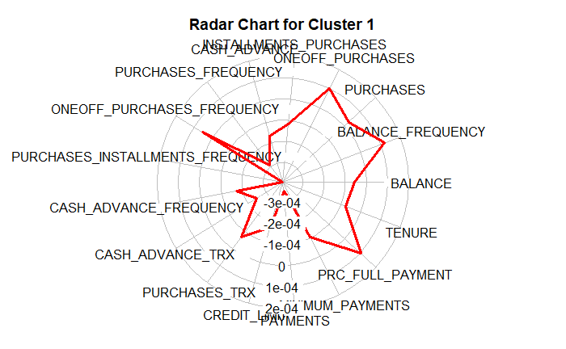

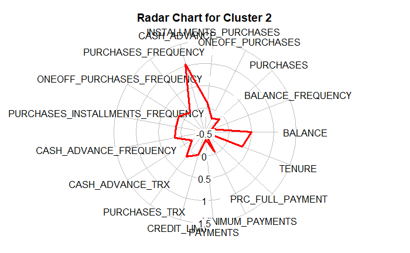

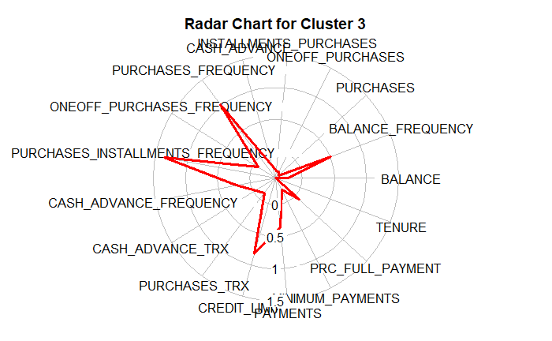

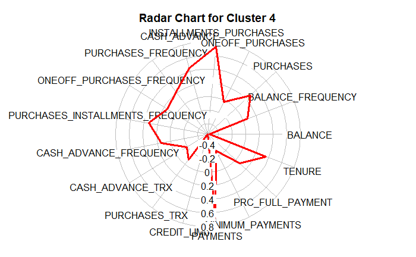

```r
for (i in 1:5){
  plot_title <- paste("Radar Chart for Cluster", i, sep=" ")
  radial.plot(hc_summary1[,i], labels = rownames(hc_summary1),
              rp.type = "p", main = plot_title,
              line.col = "red", lwd = 3, show.grid.labels=1)
}
```

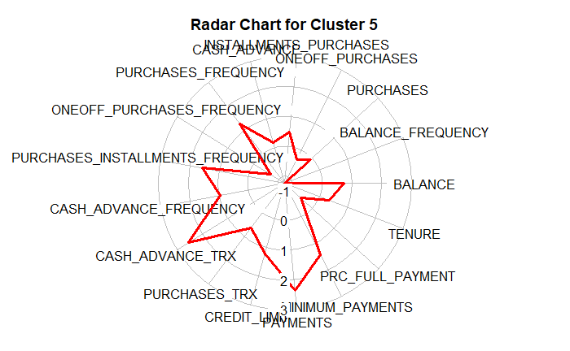

```r
NA
```

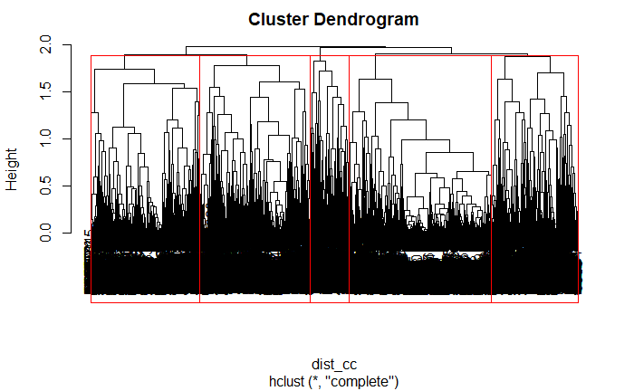

```r
mycl2 <- cutree(hr2, k=5)

plot(hr2)
rect.hclust(hr2, k=5, border="red")
```

```r
cc_hc2 <- data.frame(cc.stand, clusterID = as.factor(mycl2))
hc_summary2 <- data.frame()

for (i in 1:(ncol(cc_hc2)-1)){
  hc_summary2 = rbind(hc_summary2,
                     tapply(cc_hc2[,i], cc_hc2$clusterID, mean))
}

colnames(hc_summary2) <- paste("cluster", c(1:5))
rownames(hc_summary2) <- c(colnames(cc.stand))
round(hc_summary2, digits= 5)
```

|  | cluster 1 | cluster 2 | cluster 3 | cluster 4 | cluster 5 |
| --- | --- | --- | --- | --- | --- |
| BALANCE | 0.48895 | 0.36132 | -0.03569 | 0.02518 | -0.63918 |
| BALANCE_FREQUENCY | 0.37780 | 0.07564 | 0.09134 | 0.20480 | -0.51119 |
| PURCHASES | -0.09395 | -0.40779 | 0.02618 | 0.25307 | 0.28660 |
| ONEOFF_PURCHASES | -0.18537 | -0.29228 | 0.24549 | 0.08857 | 0.16060 |
| INSTALLMENTS_PURCHASES | 0.11860 | -0.42704 | -0.38896 | 0.43553 | 0.38230 |
| CASH_ADVANCE | 0.59398 | 0.60797 | -0.24065 | -0.35343 | -0.45118 |
| PURCHASES_FREQUENCY | 0.58541 | -1.11865 | -0.19915 | 0.88684 | 0.50965 |
| ONEOFF_PURCHASES_FREQUENCY | -0.18770 | -0.56395 | 0.59861 | 0.23206 | 0.08880 |
| PURCHASES_INSTALLMENTS_FREQUENCY | 0.69671 | -0.88751 | -0.78666 | 0.98974 | 0.53301 |
| CASH_ADVANCE_FREQUENCY | 0.98644 | 0.78071 | -0.23968 | -0.51519 | -0.65139 |

[output cut: 7 more lines]

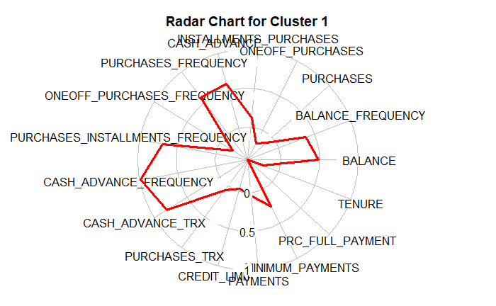

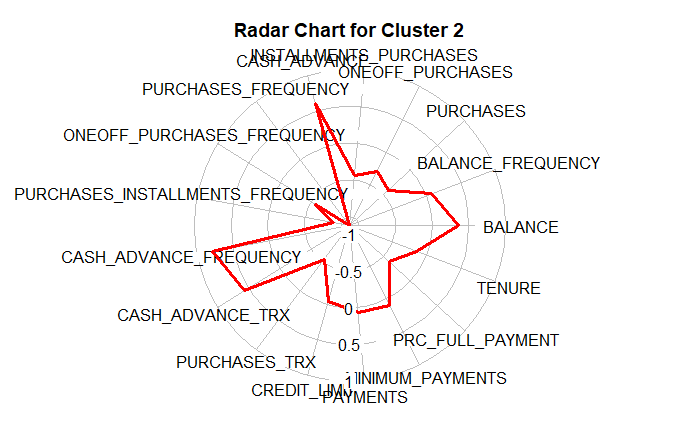

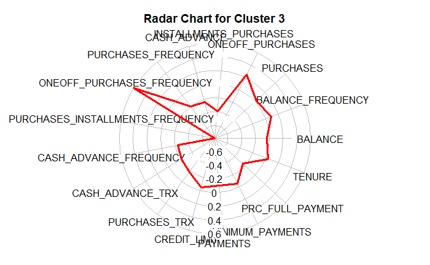

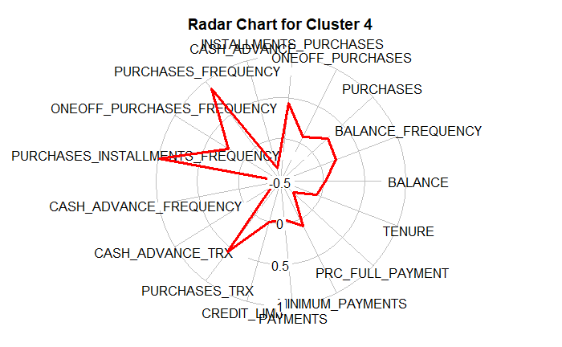

```r
for (i in 1:5){
  plot_title <- paste("Radar Chart for Cluster", i, sep=" ")
  radial.plot(hc_summary2[,i], labels = rownames(hc_summary2),
              rp.type = "p", main = plot_title,
              line.col = "red", lwd = 3, show.grid.labels=1)
}
```

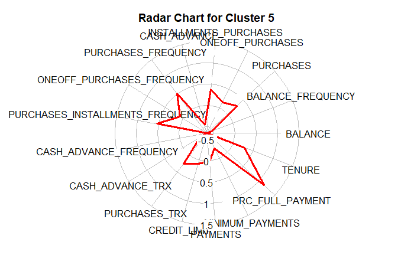

```r
NA
```

## [Q8] Single Linkage와 Complete Linkage을 사용한 군집 결과물 중 어떤 결과물이 [Q4]에서 찾은 KMeans Clustering과 더 유사한지를 정량적으로 측정할 수 있는 아이디어를 제시하고 해당 아이디어를 구현해서 비교해보시오.

각 군집에 속해있는 데이터의 유사도를 비교한다. 예를 들어, 1번 군집에 같은 데이터가 많이 들어가 있을 수록 유사도가 높다고 판단한다.

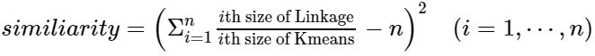

regression의 least square 방법에서 아이디어를 얻어와서 비슷한 방법을 사용한다. 식의 결과값이 작을 수록 유사도하다고 판단할 수 있다. 식의 우변의 오른쪽 항은 클러스터 2개의 사이즈가 동일한 경우(최적)을 의미한다. 이 아이디어로 계산하는 경우 single linkage의 유사도는 5.04, complete linkage의 유사도는 4.50로 나타난다. 따라서 후자의 값이 더 작기 때문에 유사도가 높다고 결론지을 수 있다.

아쉬운 점은 single linkage의 크기는 (1, 1, 1, 1, 8632)로 하나의 군집으로 쏠려있는 잘못된 모델인데, 균형있게 나누어진 complete linkage와 유사도의 차이가 그렇게 크게 나지 않는다는 아쉬움이있다.

```r
similarity <- function(linkage, base){

  sim <- (sum(linkage/base) - length(base))^2
  return(sim)

}


a <- cc.kmc1$size
a <- sort(a)

b <- c(sum(mycl2==1), sum(mycl2==2), sum(mycl2==3), sum(mycl2==4) , sum(mycl2==5))
b <- sort(b)

c <- c(sum(mycl1==1), sum(mycl1==2), sum(mycl1==3), sum(mycl1==4) , sum(mycl1==5))
c <- sort(c)

similarity(b,a)
```

```
[1] 4.50363
```

```r
similarity(c,a)
```

```
[1] 5.040384
```

# [DBSCAN]

## [Q9] dbscan( )함수의 eps 옵션과 minPts 옵션을 조정해가면서 [Q2]에서 선정한 최적 개수의 군집이 찾아지는 eps 값과 minPts 값을 찾아보시오.

(eps = 0.9 , minPts = 7) 또는 (eps = 0.7, minPts = 10)일때 k=5의 최적 군집이 찾아진다. 하지만 각 군집의 사이즈는 K-means 모델과 상당히 다르다. dbscan 모델은 반이상의 데이터가 노이즈로 제외되어, 클러스터 1개에 데이터가 밀집되어있고, 나머지 군집에는 데이터 수가 거의 없다.

```r
dbscan.list <- matrix(0, nrow = 36, ncol = 3)
colnames(dbscan.list) <- c("eps", "minPts", "size")
rownames(dbscan.list) <- paste("iter", c(1:36))

k=1
for (i in c(0.5, 0.6, 0.7, 0.8, 0.9, 1.0)){
  for (j in c(5, 6, 7, 8, 9, 10)){

    cc.dbscan <- dbscan(cc.stand, eps = i, minPts = j)
    cc.dbscan

    temp.size <- length(unique(cc.dbscan$cluster))
    dbscan.list[k ,] <- c(i, j, temp.size)
    k= k+1
    }
}

dbscan.list
```

```
        eps minPts size
iter 1  0.5      5   37
iter 2  0.5      6   21
iter 3  0.5      7   17
iter 4  0.5      8   12
iter 5  0.5      9   13
iter 6  0.5     10    7
iter 7  0.6      5   39
iter 8  0.6      6   18
iter 9  0.6      7   18
iter 10 0.6      8   16
iter 11 0.6      9   12
iter 12 0.6     10    9
iter 13 0.7      5   26
iter 14 0.7      6   19
iter 15 0.7      7   15
iter 16 0.7      8   14
iter 17 0.7      9   11
iter 18 0.7     10    6
iter 19 0.8      5   17
iter 20 0.8      6   10
iter 21 0.8      7    9
iter 22 0.8      8   11
iter 23 0.8      9    8
iter 24 0.8     10    9
iter 25 0.9      5   18
iter 26 0.9      6   10
iter 27 0.9      7    6
iter 28 0.9      8    5
iter 29 0.9      9   10
iter 30 0.9     10    9
iter 31 1.0      5   20
iter 32 1.0      6    9
iter 33 1.0      7    7
iter 34 1.0      8    5
iter 35 1.0      9    4
iter 36 1.0     10    4
```

```r
cc.db1 <- dbscan(cc.stand, eps = 0.7, minPts = 10)
cc.db1
```

```
DBSCAN clustering for 8636 objects.
Parameters: eps = 0.7, minPts = 10
The clustering contains 5 cluster(s) and 5578 noise points.

   0    1    2    3    4    5
5578 2985   32   14   17   10

Available fields: cluster, eps, minPts
```

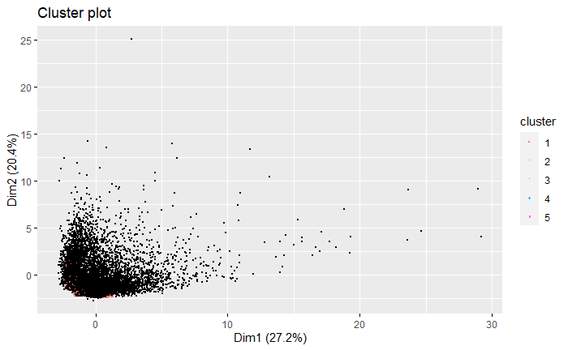

```r
fviz_cluster(cc.db1, cc.stand, ellipse = FALSE , geom = "point", pointsize = 0.1)
```

## [Q10] [Q9]에서 찾은 군집화 결과물에서 Noise로 판별된 객체의 수가 몇 개인지 확인해 보시오.

#[종합]

## [Q11] 이 데이터셋에 가장 적합한 군집화 알고리즘은 무엇이라고 생각하는지 본인이 생각한 근거를 이용하여 서술하시오.

우선, DBSCAN 알고리즘은 가장 적합하지 않은 알고리즘이라고 생각한다. 데이터가 DBSCAN 방법으로 데이터 그룹을 나누기 어려운 형태이다. 위의 문제에서 억지로 그룹을 나눈 결과가 대부분의 데이터를 노이즈로 처리한 것, 그리고 하나의 군집에 대부분의 데이터가 쏠린 형태 두가지이다. 즉 DBSCAN은 해당 데이터셋에 좋지 않은 알고리즘이다.

다음으로, 남은 KMeans와 Hierarchical 알고리즘 중에서 이 데이터 셋에 가장 적합한 알고리즘은 Hierarchical 알고리즘이라고 생각한다. 처음에 데이터를 선택한 이유와 설정한 가정을 생각해보자. 데이터가 흥미로웠던 이유는 신용카드 사용 고객을 군집화하여 적절한 마케팅 전략을 세운다는 데이터셋의 목적이었고, 마케팅 부서에서 고객은 4분류로 나누어서 전략을 수립한다고 가정을 하고 군집화를 시작하였다. 그 때의 최적의 k값이 2 또는 5가 나와서 k=5로 나눈후 2개의 밀접한 클러스터를 합쳐서 총 4개로 군집을 생성한다는 결론을 내렸다.

이 때 K-Means 알고리즘의 크기는 (3140, 3003, 1246, 978, 269)개 이다. DBSCAN 보다 데이터가 쏠리지는 않았으나, 어느정도는 쏠려있다. 게다가 어느 군집 2개를 선택해서 1개로 통합해야하는지 기준이 모호하다. 일반적으로 가장 가까운 군집 2개를 하나로 설정 하면 되지만 만약에 그 군집이 3140개, 3003개에 해당하는 군집이라면 모델링이 적합하지 않을 수 있다.

반면, Hierarchcial 알고리즘에서 compete 방식을 사용한 모델의 크기는 (2518, 1958, 1937, 1540, 683)으로 상대적으로 균등하다. 게다가 덴드로그램을 통해 어떠한 군집 2개를 선택해서 1개로 통합해야하는지 기준을 알 수 있다. 이 데이터셋에서는 그래프 상에서 3번째와 4번째의 군집을 하나로 하면 적절하다. 따라서 Hierarchical 알고리즘이 가장 적합하다고 생각한다.